# Modelo predictivo de desnutrición aguda a partir de factores medioambientales

Luis Revilla

01 junio 2023

## Librerías

Selección de todas las librerías para modelar y entrenar, desde preprocesamiento hasta validación cruzada y optimización de hiperparámetros

```r
library(tidymodels)
library(haven)
library(magrittr)
library(fs)
library(readr)
library(dplyr)
library(dials)
library(corrplot)
library(ggplot2)
library(yardstick)
library(randomForest)
library(DiagrammeR)
```

## Carga de datasets

```r
# Cargar la función

source("load_data.R")
dataset <- load_data()

malnutrition_14 <- dataset$malnutrition_14
malnutrition_15 <- dataset$malnutrition_15
malnutrition_14 <- dataset$malnutrition_14
malnutrition_16 <- dataset$malnutrition_16
malnutrition_17 <- dataset$malnutrition_17
malnutrition_18 <- dataset$malnutrition_18
malnutrition_19 <- dataset$malnutrition_19
```

## Analisis Exploratorio de la Data

### Correlación

En primer lugar, verificamos cómo se comportan las variables unas con otras, para seleccionar aquellas que no tengan tan alta correlación entre sí, debido a que dependiendo del modelo esta colinealidad podría afectar su desempeño.

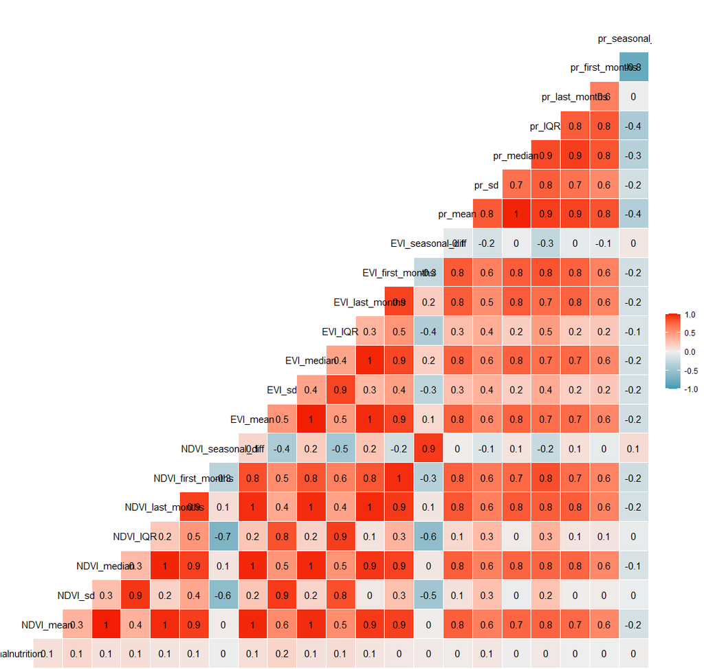

Matriz de correlación de las variables climatológicas. Fuente: Elaboración propia

### Histogramas

Consecuentemente, queremos ver las distribuciones de las variables y comprobar si tienen distribuciones normales o si por el contrario presentan alguna forma distinta, de esta manera podemos escoger una estrategia de escalamiento de los datos.

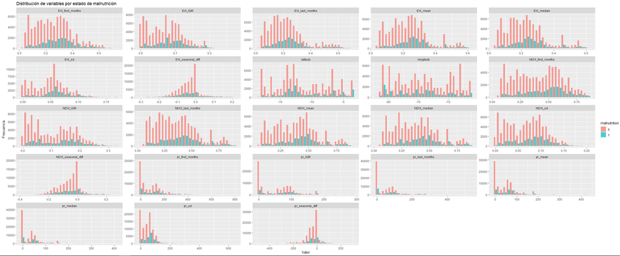

Histograma (distribución) de cada variable en los niveles de desnutrición aguda. Fuente: Elaboración propia

### Cajas y bigotes

Finalmente, visualizamos cajas y bigotes para visualizar de forma general la cantidad de outliers de las diferentes variables y al mismo tiempo verificar si las distribuciones entre observaciones de niños con o sin desnutrición son similares o difieren en cuartiles, rango, etc.

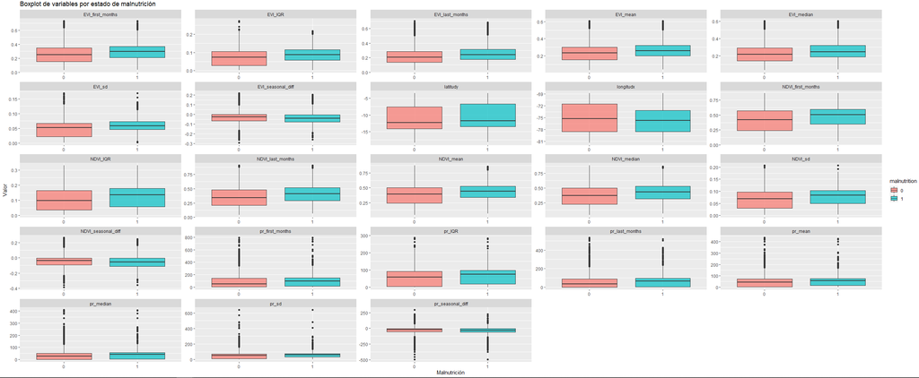

Gráfico de cajas y bigotes para cada variable climatológica en los niveles de desnutrición. Fuente: Elaboración Propia

## Pre procesamiento

Seleccionamos el training y test set. En el caso del entrenamiento tomamos los años 2014 a X. Test sería el año siguiente a X.

```r
# Training set

training_set <- data.frame(rbind(malnutrition_14, malnutrition_15,
                                 malnutrition_16, malnutrition_17,
                                 malnutrition_18)) %>%
  dplyr::select(
    malnutrition, NDVI_mean, NDVI_sd, NDVI_median, NDVI_IQR,
    NDVI_last_months, NDVI_first_months, NDVI_seasonal_diff,
    pr_mean, pr_sd, pr_median, pr_IQR, pr_last_months,
    pr_first_months, pr_seasonal_diff) %>%
  mutate(malnutrition = factor(malnutrition))


# Test set

test_set <- malnutrition_19 %>%
  dplyr::select(
    malnutrition, NDVI_mean, NDVI_sd, NDVI_median, NDVI_IQR,
    NDVI_last_months, NDVI_first_months, NDVI_seasonal_diff,
    pr_mean, pr_sd, pr_median, pr_IQR, pr_last_months,
    pr_first_months, pr_seasonal_diff) %>%
  mutate(malnutrition = factor(malnutrition))
```

## Cross validation - Hyperparameters Optimization

Utilizamos una búsqueda de valores aleatorios y dividimos 3 folds de validación. Los hiperparámetros a configurar son: mtry, min_n y trees.

```r
set.seed(1501)

#Train test split

data_train <- training_set
data_test  <- test_set

# Crear un objeto recipe para preprocesamiento
rec <- recipe(malnutrition ~ ., data = data_train) %>%
  step_center(all_numeric()) %>%
  step_scale(all_numeric())

# Preprocesamiento
rec_preprocessed <- prep(rec)

# Aplicar receta de preprocesamiento a los datos
malnutrition_preprocessed <-
  recipes::bake(
    rec_preprocessed,
    new_data = data_train
  ) %>%
  rsample::vfold_cv(v = 3, strata = "malnutrition", breaks = 5)

# Definir la fórmula del modelo
formula <- "malnutrition ~ ."

rf_spec <- rand_forest(
  mtry = tune(),
  min_n = tune(),
  trees = tune()
) %>%
  set_engine("randomForest") %>%
  set_mode("classification")

rf_params <-
  dials::parameters(
    mtry(),
    min_n(),
    trees()
  ) %>%
  dials::finalize(data_train %>% select(-malnutrition))

rf_grid <-
  dials::grid_random(
    rf_params,
    size = 50
  )

knitr::kable(head(rf_grid))
```

| mtry | min_n | trees |
| --- | --- | --- |
| 10 | 40 | 17 |
| 7 | 22 | 273 |
| 5 | 24 | 407 |
| 9 | 36 | 1336 |
| 7 | 33 | 577 |
| 7 | 40 | 527 |

```r
rf_wf <-
  workflows::workflow() %>%
  add_model(rf_spec) %>%
  add_formula(malnutrition ~ .)

train_processed <- bake(rec_preprocessed,  new_data = data_train)
```

A partir de acá, se hace la búsqueda de hiperparámetros y el cross-validation.

```r
# Sintonización de hiperparámetros
rf_tuned <- tune::tune_grid(
  object = rf_wf,
  resamples = malnutrition_preprocessed,
  grid = rf_grid,
  metrics = yardstick::metric_set(accuracy, f_meas),
  control = tune::control_grid(verbose = TRUE)
)
```

### Muestra de hiperparámetros probados

```r
params_rf_ndvi <- rf_tuned %>%
  tune::show_best(metric = "f_meas") %>%
  dplyr::slice(1:20) %>%
  knitr::kable() %>%
  kable_styling("striped")

models_results<- collect_metrics(rf_tuned)
```

### 2014 para 2015

```
## # A tibble: 30 x 9
##     mtry trees min_n .metric  .estimator  mean     n std_err .config
##    <dbl> <dbl> <dbl> <chr>    <chr>      <dbl> <dbl>   <dbl> <chr>
##  1     7  1765    28 accuracy binary     0.822     3 0.00180 Model01
##  2     7  1765    28 f_meas   binary     0.894     3 0.00129 Model01
##  3     7   587    26 accuracy binary     0.823     3 0.00223 Model02
##  4     7   587    26 f_meas   binary     0.894     3 0.00157 Model02
##  5    12  1384    10 accuracy binary     0.824     3 0.00132 Model03
##  6    12  1384    10 f_meas   binary     0.895     3 0.00121 Model03
##  7     5   757     5 accuracy binary     0.824     3 0.00139 Model04
##  8     5   757     5 f_meas   binary     0.895     3 0.00127 Model04
##  9     1   930     8 accuracy binary     0.825     3 0.00139 Model05
## 10     1   930     8 f_meas   binary     0.895     3 0.00118 Model05
## # i 20 more rows
```

### 2014-2015 para 2016

```
## # A tibble: 30 x 9
##     mtry trees min_n .metric  .estimator  mean     n  std_err .config
##    <dbl> <dbl> <dbl> <chr>    <chr>      <dbl> <dbl>    <dbl> <chr>
##  1    10  1004    23 accuracy binary     0.808     3 0.000427 Model01
##  2    10  1004    23 f_meas   binary     0.887     3 0.000237 Model01
##  3    14  1371    10 accuracy binary     0.807     3 0.000654 Model02
##  4    14  1371    10 f_meas   binary     0.887     3 0.000379 Model02
##  5    12  1784     7 accuracy binary     0.808     3 0.000212 Model03
##  6    12  1784     7 f_meas   binary     0.887     3 0.000113 Model03
##  7     3  1353    35 accuracy binary     0.808     3 0.000486 Model04
##  8     3  1353    35 f_meas   binary     0.888     3 0.000436 Model04
##  9    12  1721    10 accuracy binary     0.808     3 0.000417 Model05
## 10    12  1721    10 f_meas   binary     0.887     3 0.000237 Model05
## # i 20 more rows
```

### 2014-2016 para 2017

```
## # A tibble: 30 x 9
##     mtry trees min_n .metric  .estimator  mean     n  std_err .config
##    <dbl> <dbl> <dbl> <chr>    <chr>      <dbl> <dbl>    <dbl> <chr>
##  1    12   383    31 accuracy binary     0.817     3 0.00129  Model01
##  2    12   383    31 f_meas   binary     0.892     3 0.000968 Model01
##  3     1   621    25 accuracy binary     0.817     3 0.00174  Model02
##  4     1   621    25 f_meas   binary     0.893     3 0.00121  Model02
##  5    15  1517     2 accuracy binary     0.817     3 0.000960 Model03
##  6    15  1517     2 f_meas   binary     0.892     3 0.000693 Model03
##  7     8  1437    21 accuracy binary     0.818     3 0.000973 Model04
##  8     8  1437    21 f_meas   binary     0.892     3 0.000699 Model04
##  9    11  1520     6 accuracy binary     0.817     3 0.000638 Model05
## 10    11  1520     6 f_meas   binary     0.892     3 0.000521 Model05
## # i 20 more rows
```

### 2014-2017 para 2018

```
## # A tibble: 30 x 9
##     mtry trees min_n .metric  .estimator  mean     n  std_err .config
##    <dbl> <dbl> <dbl> <chr>    <chr>      <dbl> <dbl>    <dbl> <chr>
##  1     5   670    15 accuracy binary     0.817     3 0.00166  Model01
##  2     5   670    15 f_meas   binary     0.892     3 0.000971 Model01
##  3     5   413    21 accuracy binary     0.818     3 0.00173  Model02
##  4     5   413    21 f_meas   binary     0.892     3 0.00101  Model02
##  5     6    24    30 accuracy binary     0.816     3 0.00111  Model03
##  6     6    24    30 f_meas   binary     0.892     3 0.000634 Model03
##  7     7  1206     6 accuracy binary     0.818     3 0.00184  Model04
##  8     7  1206     6 f_meas   binary     0.892     3 0.00107  Model04
##  9    15  1109    40 accuracy binary     0.817     3 0.000939 Model05
## 10    15  1109    40 f_meas   binary     0.892     3 0.000573 Model05
## # i 20 more rows
```

### 2014-2018 para 2019

```
## # A tibble: 30 x 9
##     mtry trees min_n .metric  .estimator  mean     n  std_err .config
##    <dbl> <dbl> <dbl> <chr>    <chr>      <dbl> <dbl>    <dbl> <chr>
##  1    15  1597     4 accuracy binary     0.822     3 0.000944 Model01
##  2    15  1597     4 f_meas   binary     0.894     3 0.000633 Model01
##  3    13  1199    20 accuracy binary     0.823     3 0.000826 Model02
##  4    13  1199    20 f_meas   binary     0.894     3 0.000585 Model02
##  5    13   593    24 accuracy binary     0.822     3 0.00102  Model03
##  6    13   593    24 f_meas   binary     0.894     3 0.000744 Model03
##  7     8  1127    19 accuracy binary     0.822     3 0.000988 Model04
##  8     8  1127    19 f_meas   binary     0.894     3 0.000663 Model04
##  9    13   838    40 accuracy binary     0.821     3 0.000716 Model05
## 10    13   838    40 f_meas   binary     0.894     3 0.000453 Model05
## # i 20 more rows
```

## Evaluación out of sample

### 2014 para 2015

### Entrenamiento y métricas de evaluación 2014 -> 2015

```r
training_set <- data.frame(malnutrition_14) %>%
  dplyr::transmute(
    area_residence, region,

    HHID,malnutrition, NDVI_mean, NDVI_sd, NDVI_median, NDVI_IQR,
    NDVI_last_months, NDVI_first_months, NDVI_seasonal_diff,
    NDVI_high_count, NDVI_low_count, NDVI_range,

    pr_mean, pr_sd, pr_median, pr_IQR, pr_last_months,
    pr_first_months, pr_seasonal_diff,
    pr_high_count, pr_low_count, pr_range,


    tmax_range, tmin_range, TGAP = TMAX - TMIN) %>%
  mutate(malnutrition = factor(malnutrition), HHID = as.numeric(HHID))# %>%
#  distinct(HHID, .keep_all = TRUE)

test_set <- malnutrition_15 %>%
  dplyr::transmute(
    area_residence, region,

    HHID,malnutrition, NDVI_mean, NDVI_sd, NDVI_median, NDVI_IQR,
    NDVI_last_months, NDVI_first_months, NDVI_seasonal_diff,
    NDVI_high_count, NDVI_low_count, NDVI_range,

    pr_mean, pr_sd, pr_median, pr_IQR, pr_last_months,
    pr_first_months, pr_seasonal_diff,
    pr_high_count, pr_low_count, pr_range,


    tmax_range, tmin_range, TGAP = TMAX - TMIN) %>%
  mutate(malnutrition = factor(malnutrition) , HHID = as.numeric(HHID))# %>%
#  distinct(HHID, .keep_all = TRUE)

# Crear un objeto recipe para preprocesamiento
rec <- recipe(malnutrition ~ ., data = training_set) %>%
  update_role(HHID, new_role = "ID") %>%
  step_center(all_numeric()) %>%
  step_scale(all_numeric())

# Preprocesamiento
rec_preprocessed <- prep(rec)

train_processed  <- bake(rec_preprocessed, new_data = training_set)

test_processed  <- bake(rec_preprocessed, new_data = test_set)


rf_spec <- rand_forest(
  mtry = 3,
  min_n = 19,
  trees = 1305
) %>%
  set_engine("ranger", importance = 'impurity', regularization.factor = 0.5) %>%
  set_mode("classification")


rf_wf <-
  workflow() %>%
  add_model(rf_spec) %>%
  add_recipe(rec_preprocessed)

rf_fit <- rf_wf %>%
  fit(data = training_set)

# Predicciones para el conjunto de entrenamiento
rf_training_pred <-
  predict(rf_fit, training_set, type = "prob") %>%
  mutate(.pred_class =  as.factor(ifelse(.pred_1 > 0.2, "1", "0"))) %>%
  bind_cols(training_set %>% select(malnutrition))

rf_training_pred %>%                # training set predictions
  roc_auc(truth = malnutrition, .pred_1)
```

```
## # A tibble: 1 x 3
##   .metric .estimator .estimate
##   <chr>   <chr>          <dbl>
## 1 roc_auc binary         0.122
```

```r
rf_training_pred %>%                # training set predictions
  accuracy(truth = malnutrition, .pred_class)
```

```
## # A tibble: 1 x 3
##   .metric  .estimator .estimate
##   <chr>    <chr>          <dbl>
## 1 accuracy binary         0.934
```

```r
# Predicciones para el conjunto de prueba
rf_testing_pred <-
  predict(rf_fit, test_set, type = "prob") %>%
  mutate(.pred_class =  as.factor(ifelse(.pred_1 > 0.1, "1", "0"))) %>%
  bind_cols(test_set %>% select(malnutrition))

rf_testing_pred %>%                   # test set predictions
  roc_auc(truth = malnutrition, .pred_1)
```

```
## # A tibble: 1 x 3
##   .metric .estimator .estimate
##   <chr>   <chr>          <dbl>
## 1 roc_auc binary         0.381
```

```r
rf_testing_pred %>%                   # test set predictions
  accuracy(truth = malnutrition, .pred_class)
```

```
## # A tibble: 1 x 3
##   .metric  .estimator .estimate
##   <chr>    <chr>          <dbl>
## 1 accuracy binary         0.711
```

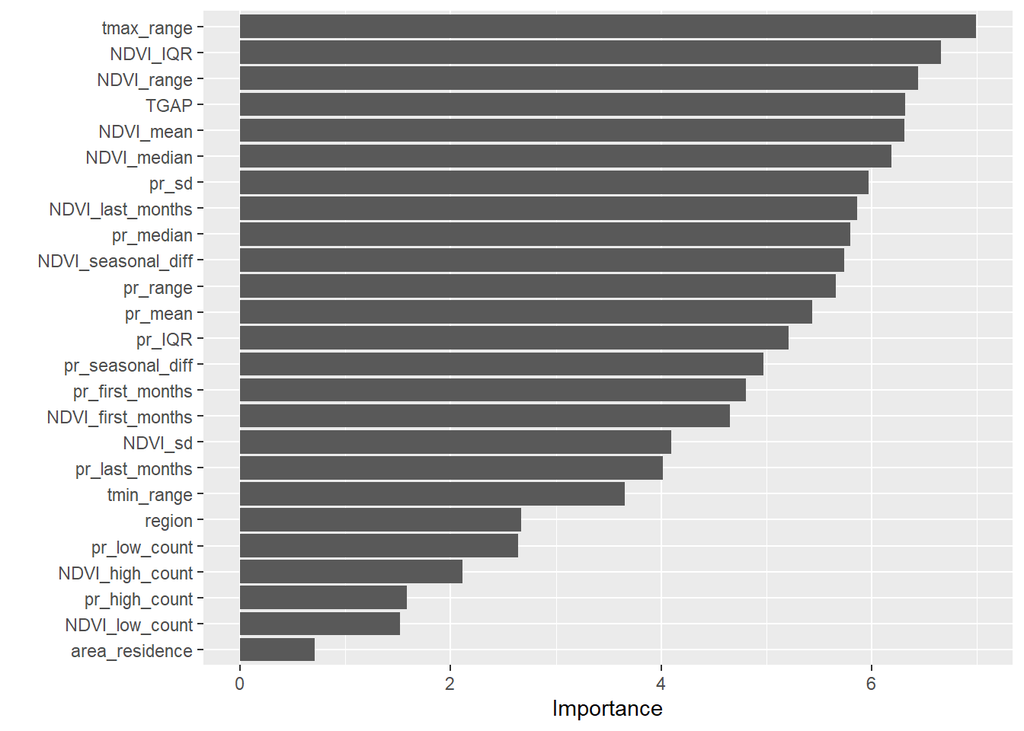

```r
library(vip)

# Extraer el modelo ajustado del flujo de trabajo
rf_model <- pull_workflow_fit(rf_fit)

num_features <- ncol(training_set) - 1

# Generar el gráfico de importancia de variables
vip(rf_model, method = "model", num_features = num_features)
```

### Otras métricas

```r
# VPP (Valor Predictivo Positivo)
rf_training_pred %>%
  ppv(truth = malnutrition, .pred_class)
```

```
## # A tibble: 1 x 3
##   .metric .estimator .estimate
##   <chr>   <chr>          <dbl>
## 1 ppv     binary         0.964
```

```r
rf_testing_pred %>%
  ppv(truth = malnutrition, .pred_class)
```

```
## # A tibble: 1 x 3
##   .metric .estimator .estimate
##   <chr>   <chr>          <dbl>
## 1 ppv     binary         0.961
```

```r
# VPN (Valor Predictivo Negativo)
rf_training_pred %>%
  npv(truth = malnutrition, .pred_class)
```

```
## # A tibble: 1 x 3
##   .metric .estimator .estimate
##   <chr>   <chr>          <dbl>
## 1 npv     binary         0.307
```

```r
rf_testing_pred %>%
  npv(truth = malnutrition, .pred_class)
```

```
## # A tibble: 1 x 3
##   .metric .estimator .estimate
##   <chr>   <chr>          <dbl>
## 1 npv     binary        0.0707
```

```r
# F1-score
rf_training_pred %>%
  f_meas(truth = malnutrition, .pred_class)
```

```
## # A tibble: 1 x 3
##   .metric .estimator .estimate
##   <chr>   <chr>          <dbl>
## 1 f_meas  binary         0.965
```

```r
rf_testing_pred %>%
  f_meas(truth = malnutrition, .pred_class)
```

```
## # A tibble: 1 x 3
##   .metric .estimator .estimate
##   <chr>   <chr>          <dbl>
## 1 f_meas  binary         0.827
```

```r
# Matriz de confusión para el conjunto de entrenamiento
rf_training_conf_mat <-
  rf_training_pred %>%
  conf_mat(truth = malnutrition, estimate = .pred_class)

print(rf_training_conf_mat)
```

```
##           Truth
## Prediction    0    1
##          0 6843  254
##          1  241  107
```

```r
# Matriz de confusión para el conjunto de prueba
rf_testing_conf_mat <-
  rf_testing_pred %>%
  conf_mat(truth = malnutrition, estimate = .pred_class)

print(rf_testing_conf_mat)
```

```
##           Truth
## Prediction     0     1
##          0 14755   603
##          1  5577   424
```

```
##
## Accuracy: 0.5631324
```

```
## Recall: 0.6048944
```

### 2014-2015 para 2016

### Entrenamiento y métricas de evaluación 2014 -> 2016

```r
training_set <- data.frame(rbind(malnutrition_14, malnutrition_15)) %>%
  dplyr::transmute(
    area_residence, region,

    HHID,malnutrition, NDVI_mean, NDVI_sd, NDVI_median, NDVI_IQR,
    NDVI_last_months, NDVI_first_months, NDVI_seasonal_diff,
    NDVI_high_count, NDVI_low_count, NDVI_range,

    pr_mean, pr_sd, pr_median, pr_IQR, pr_last_months,
    pr_first_months, pr_seasonal_diff,
    pr_high_count, pr_low_count, pr_range,


    tmax_range, tmin_range, TGAP = TMAX - TMIN) %>%
  mutate(malnutrition = factor(malnutrition), HHID = as.numeric(HHID))# %>%
#  distinct(HHID, .keep_all = TRUE)

test_set <- malnutrition_16 %>%
  dplyr::transmute(
    area_residence, region,

    HHID,malnutrition, NDVI_mean, NDVI_sd, NDVI_median, NDVI_IQR,
    NDVI_last_months, NDVI_first_months, NDVI_seasonal_diff,
    NDVI_high_count, NDVI_low_count, NDVI_range,

    pr_mean, pr_sd, pr_median, pr_IQR, pr_last_months,
    pr_first_months, pr_seasonal_diff,
    pr_high_count, pr_low_count, pr_range,


    tmax_range, tmin_range, TGAP = TMAX - TMIN) %>%
  mutate(malnutrition = factor(malnutrition) , HHID = as.numeric(HHID))# %>%
#  distinct(HHID, .keep_all = TRUE)

# Crear un objeto recipe para preprocesamiento
rec <- recipe(malnutrition ~ ., data = training_set) %>%
  update_role(HHID, new_role = "ID") %>%
  step_center(all_numeric()) %>%
  step_scale(all_numeric())

# Preprocesamiento
rec_preprocessed <- prep(rec)

train_processed  <- bake(rec_preprocessed, new_data = training_set)

test_processed  <- bake(rec_preprocessed, new_data = test_set)


rf_spec <- rand_forest(
  mtry = 3,
  min_n = 35,
  trees = 1353
) %>%
  set_engine("ranger", importance = 'impurity', regularization.factor = 0.5) %>%
  set_mode("classification")


rf_wf <-
  workflow() %>%
  add_model(rf_spec) %>%
  add_recipe(rec_preprocessed)

rf_fit <- rf_wf %>%
  fit(data = training_set)

# Predicciones para el conjunto de entrenamiento
rf_training_pred <-
  predict(rf_fit, training_set, type = "prob") %>%
  mutate(.pred_class =  as.factor(ifelse(.pred_1 > 0.2, "1", "0"))) %>%
  bind_cols(training_set %>% select(malnutrition))

rf_training_pred %>%                # training set predictions
  roc_auc(truth = malnutrition, .pred_1)
```

```
## # A tibble: 1 x 3
##   .metric .estimator .estimate
##   <chr>   <chr>          <dbl>
## 1 roc_auc binary         0.146
```

```r
rf_training_pred %>%                # training set predictions
  accuracy(truth = malnutrition, .pred_class)
```

```
## # A tibble: 1 x 3
##   .metric  .estimator .estimate
##   <chr>    <chr>          <dbl>
## 1 accuracy binary         0.938
```

```r
# Predicciones para el conjunto de prueba
rf_testing_pred <-
  predict(rf_fit, test_set, type = "prob") %>%
  mutate(.pred_class =  as.factor(ifelse(.pred_1 > 0.1, "1", "0"))) %>%
  bind_cols(test_set %>% select(malnutrition))

rf_testing_pred %>%                   # test set predictions
  roc_auc(truth = malnutrition, .pred_1)
```

```
## # A tibble: 1 x 3
##   .metric .estimator .estimate
##   <chr>   <chr>          <dbl>
## 1 roc_auc binary         0.400
```

```r
rf_testing_pred %>%                   # test set predictions
  accuracy(truth = malnutrition, .pred_class)
```

```
## # A tibble: 1 x 3
##   .metric  .estimator .estimate
##   <chr>    <chr>          <dbl>
## 1 accuracy binary         0.747
```

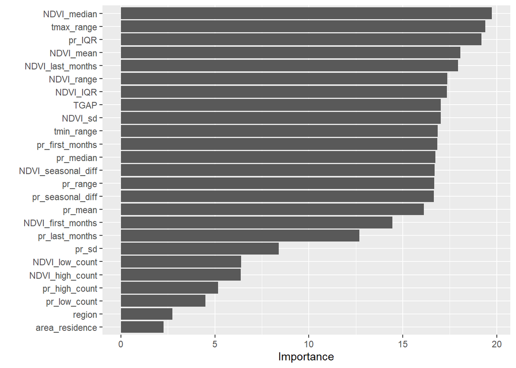

```r
library(vip)

# Extraer el modelo ajustado del flujo de trabajo
rf_model <- pull_workflow_fit(rf_fit)

num_features <- ncol(training_set) - 1

# Generar el gráfico de importancia de variables
vip(rf_model, method = "model", num_features = num_features)
```

### Otras métricas

```r
# VPP (Valor Predictivo Positivo)
rf_training_pred %>%
  ppv(truth = malnutrition, .pred_class)
```

```
## # A tibble: 1 x 3
##   .metric .estimator .estimate
##   <chr>   <chr>          <dbl>
## 1 ppv     binary         0.960
```

```r
rf_testing_pred %>%
  ppv(truth = malnutrition, .pred_class)
```

```
## # A tibble: 1 x 3
##   .metric .estimator .estimate
##   <chr>   <chr>          <dbl>
## 1 ppv     binary         0.958
```

```r
# VPN (Valor Predictivo Negativo)
rf_training_pred %>%
  npv(truth = malnutrition, .pred_class)
```

```
## # A tibble: 1 x 3
##   .metric .estimator .estimate
##   <chr>   <chr>          <dbl>
## 1 npv     binary         0.287
```

```r
rf_testing_pred %>%
  npv(truth = malnutrition, .pred_class)
```

```
## # A tibble: 1 x 3
##   .metric .estimator .estimate
##   <chr>   <chr>          <dbl>
## 1 npv     binary        0.0638
```

```r
# F1-score
rf_training_pred %>%
  f_meas(truth = malnutrition, .pred_class)
```

```
## # A tibble: 1 x 3
##   .metric .estimator .estimate
##   <chr>   <chr>          <dbl>
## 1 f_meas  binary         0.968
```

```r
rf_testing_pred %>%
  f_meas(truth = malnutrition, .pred_class)
```

```
## # A tibble: 1 x 3
##   .metric .estimator .estimate
##   <chr>   <chr>          <dbl>
## 1 f_meas  binary         0.853
```

```r
# Matriz de confusión para el conjunto de entrenamiento
rf_training_conf_mat <-
  rf_training_pred %>%
  conf_mat(truth = malnutrition, estimate = .pred_class)

print(rf_training_conf_mat)
```

```
##           Truth
## Prediction     0     1
##          0 26756  1122
##          1   660   266
```

```r
# Matriz de confusión para el conjunto de prueba
rf_testing_conf_mat <-
  rf_testing_pred %>%
  conf_mat(truth = malnutrition, estimate = .pred_class)

print(rf_testing_conf_mat)
```

```
##           Truth
## Prediction     0     1
##          0 12861   557
##          1  3890   265
```

```
##
## Accuracy: 0.5893256
```

```
## Recall: 0.56317016
```

### 2014-2016 para 2017

### Entrenamiento y métricas de evaluación 2014 -> 2017

```r
training_set <- data.frame(rbind(malnutrition_14, malnutrition_15, malnutrition_16)) %>%
  dplyr::transmute(
    area_residence, region,

    HHID,malnutrition, NDVI_mean, NDVI_sd, NDVI_median, NDVI_IQR,
    NDVI_last_months, NDVI_first_months, NDVI_seasonal_diff,
    NDVI_high_count, NDVI_low_count, NDVI_range,

    pr_mean, pr_sd, pr_median, pr_IQR, pr_last_months,
    pr_first_months, pr_seasonal_diff,
    pr_high_count, pr_low_count, pr_range,


    tmax_range, tmin_range, TGAP = TMAX - TMIN) %>%
  mutate(malnutrition = factor(malnutrition), HHID = as.numeric(HHID))# %>%
#  distinct(HHID, .keep_all = TRUE)

test_set <- malnutrition_17 %>%
  dplyr::transmute(
    area_residence, region,

    HHID,malnutrition, NDVI_mean, NDVI_sd, NDVI_median, NDVI_IQR,
    NDVI_last_months, NDVI_first_months, NDVI_seasonal_diff,
    NDVI_high_count, NDVI_low_count, NDVI_range,

    pr_mean, pr_sd, pr_median, pr_IQR, pr_last_months,
    pr_first_months, pr_seasonal_diff,
    pr_high_count, pr_low_count, pr_range,


    tmax_range, tmin_range, TGAP = TMAX - TMIN) %>%
  mutate(malnutrition = factor(malnutrition) , HHID = as.numeric(HHID))# %>%
#  distinct(HHID, .keep_all = TRUE)

# Crear un objeto recipe para preprocesamiento
rec <- recipe(malnutrition ~ ., data = training_set) %>%
  update_role(HHID, new_role = "ID") %>%
  step_center(all_numeric()) %>%
  step_scale(all_numeric())

# Preprocesamiento
rec_preprocessed <- prep(rec)

train_processed  <- bake(rec_preprocessed, new_data = training_set)

test_processed  <- bake(rec_preprocessed, new_data = test_set)


rf_spec <- rand_forest(
  mtry = 1,
  min_n = 37,
  trees = 1617
) %>%
  set_engine("ranger", importance = 'impurity', regularization.factor = 0.5) %>%
  set_mode("classification")


rf_wf <-
  workflow() %>%
  add_model(rf_spec) %>%
  add_recipe(rec_preprocessed)

rf_fit <- rf_wf %>%
  fit(data = training_set)

# Predicciones para el conjunto de entrenamiento
rf_training_pred <-
  predict(rf_fit, training_set, type = "prob") %>%
  mutate(.pred_class =  as.factor(ifelse(.pred_1 > 0.2, "1", "0"))) %>%
  bind_cols(training_set %>% select(malnutrition))

rf_training_pred %>%                # training set predictions
  roc_auc(truth = malnutrition, .pred_1)
```

```
## # A tibble: 1 x 3
##   .metric .estimator .estimate
##   <chr>   <chr>          <dbl>
## 1 roc_auc binary         0.147
```

```r
rf_training_pred %>%                # training set predictions
  accuracy(truth = malnutrition, .pred_class)
```

```
## # A tibble: 1 x 3
##   .metric  .estimator .estimate
##   <chr>    <chr>          <dbl>
## 1 accuracy binary         0.948
```

```r
# Predicciones para el conjunto de prueba
rf_testing_pred <-
  predict(rf_fit, test_set, type = "prob") %>%
  mutate(.pred_class =  as.factor(ifelse(.pred_1 > 0.09, "1", "0"))) %>%
  bind_cols(test_set %>% select(malnutrition))

rf_testing_pred %>%                   # test set predictions
  roc_auc(truth = malnutrition, .pred_1)
```

```
## # A tibble: 1 x 3
##   .metric .estimator .estimate
##   <chr>   <chr>          <dbl>
## 1 roc_auc binary         0.405
```

```r
rf_testing_pred %>%                   # test set predictions
  accuracy(truth = malnutrition, .pred_class)
```

```
## # A tibble: 1 x 3
##   .metric  .estimator .estimate
##   <chr>    <chr>          <dbl>
## 1 accuracy binary         0.900
```

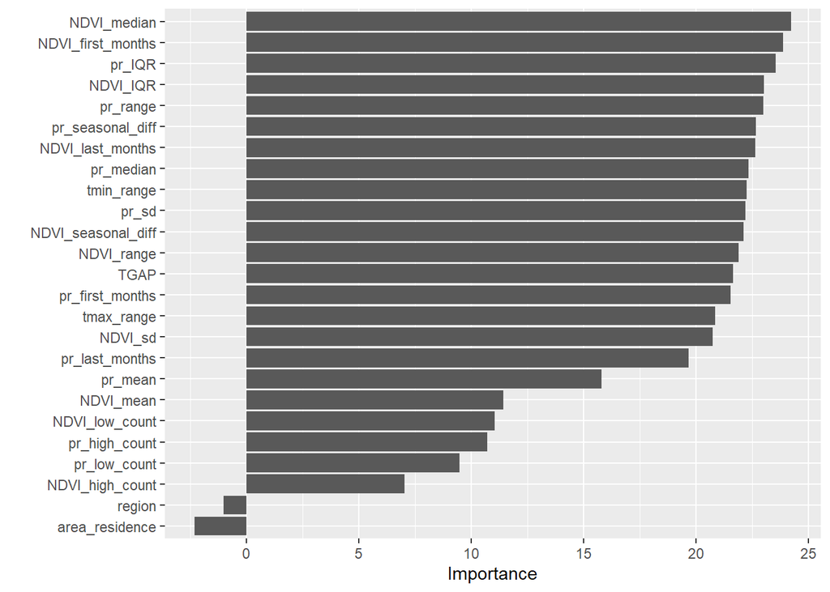

```r
library(vip)

# Extraer el modelo ajustado del flujo de trabajo
rf_model <- pull_workflow_fit(rf_fit)

num_features <- ncol(training_set) - 1

# Generar el gráfico de importancia de variables
vip(rf_model, method = "model", num_features = num_features)
```

### Otras métricas

```r
# VPP (Valor Predictivo Positivo)
rf_training_pred %>%
  ppv(truth = malnutrition, .pred_class)
```

```
## # A tibble: 1 x 3
##   .metric .estimator .estimate
##   <chr>   <chr>          <dbl>
## 1 ppv     binary         0.958
```

```r
rf_testing_pred %>%
  ppv(truth = malnutrition, .pred_class)
```

```
## # A tibble: 1 x 3
##   .metric .estimator .estimate
##   <chr>   <chr>          <dbl>
## 1 ppv     binary         0.957
```

```r
# VPN (Valor Predictivo Negativo)
rf_training_pred %>%
  npv(truth = malnutrition, .pred_class)
```

```
## # A tibble: 1 x 3
##   .metric .estimator .estimate
##   <chr>   <chr>          <dbl>
## 1 npv     binary         0.377
```

```r
rf_testing_pred %>%
  npv(truth = malnutrition, .pred_class)
```

```
## # A tibble: 1 x 3
##   .metric .estimator .estimate
##   <chr>   <chr>          <dbl>
## 1 npv     binary        0.0645
```

```r
# F1-score
rf_training_pred %>%
  f_meas(truth = malnutrition, .pred_class)
```

```
## # A tibble: 1 x 3
##   .metric .estimator .estimate
##   <chr>   <chr>          <dbl>
## 1 f_meas  binary         0.973
```

```r
rf_testing_pred %>%
  f_meas(truth = malnutrition, .pred_class)
```

```
## # A tibble: 1 x 3
##   .metric .estimator .estimate
##   <chr>   <chr>          <dbl>
## 1 f_meas  binary         0.947
```

```r
# Matriz de confusión para el conjunto de entrenamiento
rf_training_conf_mat <-
  rf_training_pred %>%
  conf_mat(truth = malnutrition, estimate = .pred_class)

print(rf_training_conf_mat)
```

```
##           Truth
## Prediction     0     1
##          0 43654  1900
##          1   513   310
```

```r
# Matriz de confusión para el conjunto de prueba
rf_testing_conf_mat <-
  rf_testing_pred %>%
  conf_mat(truth = malnutrition, estimate = .pred_class)

print(rf_testing_conf_mat)
```

```
##           Truth
## Prediction     0     1
##          0 16879   764
##          1  1117    77
```

[output not shown]

[output not shown]

### 2014-2017 para 2018

```r
training_set <- data.frame(rbind(malnutrition_14, malnutrition_15, malnutrition_16, malnutrition_17)) %>%
  dplyr::transmute(
    HHID,malnutrition, NDVI_mean, NDVI_sd, NDVI_median, NDVI_IQR,
    NDVI_last_months, NDVI_first_months, NDVI_seasonal_diff,
    pr_mean, pr_sd, pr_median, pr_IQR, pr_last_months,
    pr_first_months, pr_seasonal_diff, TGAP) %>%
  mutate(malnutrition = factor(malnutrition), HHID = as.numeric(HHID))# %>%
#  distinct(HHID, .keep_all = TRUE)

test_set <- malnutrition_18 %>%
  dplyr::select(
    HHID, malnutrition, NDVI_mean, NDVI_sd, NDVI_median, NDVI_IQR,
    NDVI_last_months, NDVI_first_months, NDVI_seasonal_diff,
    pr_mean, pr_sd, pr_median, pr_IQR, pr_last_months,
    pr_first_months, pr_seasonal_diff, TGAP) %>%
  mutate(malnutrition = factor(malnutrition) , HHID = as.numeric(HHID))# %>%
#  distinct(HHID, .keep_all = TRUE)

# Crear un objeto recipe para preprocesamiento
rec <- recipe(malnutrition ~ ., data = training_set) %>%
  update_role(HHID, new_role = "ID") %>%
  step_center(all_numeric()) %>%
  step_scale(all_numeric())

# Preprocesamiento
rec_preprocessed <- prep(rec)

train_processed  <- bake(rec_preprocessed, new_data = training_set)

test_processed  <- bake(rec_preprocessed, new_data = test_set)


rf_spec <- rand_forest(
  mtry = 1,
  min_n = 38,
  trees = 80
) %>%
  set_engine("ranger", importance = 'impurity', regularization.factor = 0.5) %>%
  set_mode("classification")


rf_wf <-
  workflow() %>%
  add_model(rf_spec) %>%
  add_recipe(rec_preprocessed)

rf_fit <- rf_wf %>%
  fit(data = training_set)

rf_training_pred <-
  predict(rf_fit, training_set) %>%
  bind_cols(predict(rf_fit, training_set, type = "prob")) %>%
  # Add the true outcome data back in
  bind_cols(training_set %>%
              select(malnutrition))

rf_training_pred %>%                # training set predictions
  roc_auc(truth = malnutrition, .pred_1)

rf_training_pred %>%                # training set predictions
  accuracy(truth = malnutrition, .pred_class)

rf_testing_pred <-
  predict(rf_fit, test_set) %>%
  bind_cols(predict(rf_fit, test_set, type = "prob")) %>%
  bind_cols(test_set %>% select(malnutrition))

rf_testing_pred %>%                   # test set predictions
  roc_auc(truth = malnutrition, .pred_1)

rf_testing_pred %>%                   # test set predictions
  accuracy(truth = malnutrition, .pred_class)

library(vip)

# Extraer el modelo ajustado del flujo de trabajo
rf_model <- pull_workflow_fit(rf_fit)

# Generar el gráfico de importancia de variables
vip(rf_model, method = "model")
```

[output not shown]

```
##
## Accuracy: 0.5058414
```

```
## Recall: 0.68280614
```

### 2014-2018 para 2019

```r
training_set <- data.frame(rbind(malnutrition_14, malnutrition_15, malnutrition_16,
                                 malnutrition_17, malnutrition_18)) %>%
  dplyr::transmute(
    HHID,malnutrition, NDVI_mean, NDVI_sd, NDVI_median, NDVI_IQR,
    NDVI_last_months, NDVI_first_months, NDVI_seasonal_diff,
    pr_mean, pr_sd, pr_median, pr_IQR, pr_last_months,
    pr_first_months, pr_seasonal_diff, TGAP) %>%
  mutate(malnutrition = factor(malnutrition), HHID = as.numeric(HHID))# %>%
#  distinct(HHID, .keep_all = TRUE)

test_set <- malnutrition_19 %>%
  dplyr::select(
    HHID, malnutrition, NDVI_mean, NDVI_sd, NDVI_median, NDVI_IQR,
    NDVI_last_months, NDVI_first_months, NDVI_seasonal_diff,
    pr_mean, pr_sd, pr_median, pr_IQR, pr_last_months,
    pr_first_months, pr_seasonal_diff, TGAP) %>%
  mutate(malnutrition = factor(malnutrition) , HHID = as.numeric(HHID))# %>%
#  distinct(HHID, .keep_all = TRUE)

# Crear un objeto recipe para preprocesamiento
rec <- recipe(malnutrition ~ ., data = training_set) %>%
  update_role(HHID, new_role = "ID") %>%
  step_center(all_numeric()) %>%
  step_scale(all_numeric())

# Preprocesamiento
rec_preprocessed <- prep(rec)

train_processed  <- bake(rec_preprocessed, new_data = training_set)

test_processed  <- bake(rec_preprocessed, new_data = test_set)


rf_spec <- rand_forest(
  mtry = 1,
  min_n = 27,
  trees = 1538
) %>%
  set_engine("ranger", importance = 'impurity', regularization.factor = 0.5) %>%
  set_mode("classification")


rf_wf <-
  workflow() %>%
  add_model(rf_spec) %>%
  add_recipe(rec_preprocessed)

rf_fit <- rf_wf %>%
  fit(data = training_set)

rf_training_pred <-
  predict(rf_fit, training_set) %>%
  bind_cols(predict(rf_fit, training_set, type = "prob")) %>%
  # Add the true outcome data back in
  bind_cols(training_set %>%
              select(malnutrition))

rf_training_pred %>%                # training set predictions
  roc_auc(truth = malnutrition, .pred_1)

rf_training_pred %>%                # training set predictions
  accuracy(truth = malnutrition, .pred_class)

rf_testing_pred <-
  predict(rf_fit, test_set) %>%
  bind_cols(predict(rf_fit, test_set, type = "prob")) %>%
  bind_cols(test_set %>% select(malnutrition))

rf_testing_pred %>%                   # test set predictions
  roc_auc(truth = malnutrition, .pred_1)

rf_testing_pred %>%                   # test set predictions
  accuracy(truth = malnutrition, .pred_class)

library(vip)

# Extraer el modelo ajustado del flujo de trabajo
rf_model <- pull_workflow_fit(rf_fit)

# Generar el gráfico de importancia de variables
vip(rf_model, method = "model")
```

[output not shown]

```
##
## Accuracy: 0.5460739
```

```
## Recall: 0.5483613
```

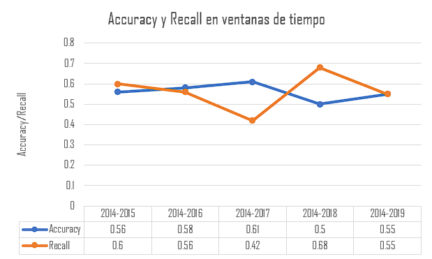

Accuracy y Recall en ventanas de tiempo del 2014 al 2019. Fuente: Elaboración Propia